# Risk Factor Analysis

## Outcome Variable

**Outcome Variable:** wasted

## Predictor Variables

**Intervention Variable:** impsan

**Adjustment Set:**

- arm
- sex
- W_mage
- meducyrs
- feducyrs
- hhwealth_quart
- hfoodsec
- W_mhtcm
- W_mwtkg
- W_mbmi
- W_nrooms
- W_nchldlt5
- W_parity
- impfloor
- safeh20
- delta_W_mage
- delta_meducyrs
- delta_feducyrs
- delta_hhwealth_quart
- delta_hfoodsec
- delta_W_mhtcm
- delta_W_mwtkg
- delta_W_mbmi
- delta_W_nrooms
- delta_W_nchldlt5
- delta_W_parity
- delta_impfloor
- delta_safeh20

## Stratifying Variables

The analysis was stratified on these variable(s):

- agecat
- studyid
- country

## Data Summary

| agecat | studyid | country | impsan | wasted | n_cell | n |
| --- | --- | --- | --- | --- | --- | --- |
| Birth | COHORTS | GUATEMALA | 1 | 0 | 28 | 449 |
| Birth | COHORTS | GUATEMALA | 1 | 1 | 15 | 449 |
| Birth | COHORTS | GUATEMALA | 0 | 0 | 312 | 449 |
| Birth | COHORTS | GUATEMALA | 0 | 1 | 94 | 449 |
| Birth | COHORTS | INDIA | 1 | 0 | 1409 | 4461 |
| Birth | COHORTS | INDIA | 1 | 1 | 276 | 4461 |
| Birth | COHORTS | INDIA | 0 | 0 | 2276 | 4461 |
| Birth | COHORTS | INDIA | 0 | 1 | 500 | 4461 |
| Birth | COHORTS | PHILIPPINES | 1 | 0 | 145 | 1126 |
| Birth | COHORTS | PHILIPPINES | 1 | 1 | 32 | 1126 |
| Birth | COHORTS | PHILIPPINES | 0 | 0 | 814 | 1126 |
| Birth | COHORTS | PHILIPPINES | 0 | 1 | 135 | 1126 |
| Birth | CONTENT | PERU | 1 | 0 | 1 | 2 |
| Birth | CONTENT | PERU | 1 | 1 | 0 | 2 |
| Birth | CONTENT | PERU | 0 | 0 | 1 | 2 |
| Birth | CONTENT | PERU | 0 | 1 | 0 | 2 |
| Birth | JiVitA-3 | BANGLADESH | 1 | 0 | 11058 | 17991 |
| Birth | JiVitA-3 | BANGLADESH | 1 | 1 | 1355 | 17991 |
| Birth | JiVitA-3 | BANGLADESH | 0 | 0 | 4961 | 17991 |
| Birth | JiVitA-3 | BANGLADESH | 0 | 1 | 617 | 17991 |
| Birth | JiVitA-4 | BANGLADESH | 1 | 0 | 1681 | 2394 |
| Birth | JiVitA-4 | BANGLADESH | 1 | 1 | 178 | 2394 |
| Birth | JiVitA-4 | BANGLADESH | 0 | 0 | 475 | 2394 |
| Birth | JiVitA-4 | BANGLADESH | 0 | 1 | 60 | 2394 |
| Birth | MAL-ED | BANGLADESH | 1 | 0 | 138 | 201 |
| Birth | MAL-ED | BANGLADESH | 1 | 1 | 30 | 201 |
| Birth | MAL-ED | BANGLADESH | 0 | 0 | 28 | 201 |
| Birth | MAL-ED | BANGLADESH | 0 | 1 | 5 | 201 |
| Birth | MAL-ED | BRAZIL | 1 | 0 | 54 | 57 |
| Birth | MAL-ED | BRAZIL | 1 | 1 | 2 | 57 |

[output cut: 170 more lines]

The following strata were considered:

- agecat: 24 months, studyid: COHORTS, country: GUATEMALA
- agecat: 24 months, studyid: COHORTS, country: INDIA
- agecat: 24 months, studyid: COHORTS, country: PHILIPPINES
- agecat: 24 months, studyid: CONTENT, country: PERU
- agecat: 24 months, studyid: JiVitA-3, country: BANGLADESH
- agecat: 24 months, studyid: JiVitA-4, country: BANGLADESH
- agecat: 24 months, studyid: LCNI-5, country: MALAWI
- agecat: 24 months, studyid: MAL-ED, country: BANGLADESH
- agecat: 24 months, studyid: MAL-ED, country: BRAZIL
- agecat: 24 months, studyid: MAL-ED, country: INDIA
- agecat: 24 months, studyid: MAL-ED, country: NEPAL
- agecat: 24 months, studyid: MAL-ED, country: PERU
- agecat: 24 months, studyid: MAL-ED, country: SOUTH AFRICA
- agecat: 24 months, studyid: MAL-ED, country: TANZANIA, UNITED REPUBLIC OF
- agecat: 24 months, studyid: NIH-Birth, country: BANGLADESH
- agecat: 24 months, studyid: NIH-Crypto, country: BANGLADESH
- agecat: 24 months, studyid: PROVIDE, country: BANGLADESH
- agecat: 6 months, studyid: COHORTS, country: GUATEMALA
- agecat: 6 months, studyid: COHORTS, country: INDIA
- agecat: 6 months, studyid: COHORTS, country: PHILIPPINES
- agecat: 6 months, studyid: CONTENT, country: PERU
- agecat: 6 months, studyid: JiVitA-3, country: BANGLADESH
- agecat: 6 months, studyid: JiVitA-4, country: BANGLADESH
- agecat: 6 months, studyid: LCNI-5, country: MALAWI
- agecat: 6 months, studyid: MAL-ED, country: BANGLADESH
- agecat: 6 months, studyid: MAL-ED, country: BRAZIL
- agecat: 6 months, studyid: MAL-ED, country: INDIA
- agecat: 6 months, studyid: MAL-ED, country: NEPAL
- agecat: 6 months, studyid: MAL-ED, country: PERU
- agecat: 6 months, studyid: MAL-ED, country: SOUTH AFRICA
- agecat: 6 months, studyid: MAL-ED, country: TANZANIA, UNITED REPUBLIC OF
- agecat: 6 months, studyid: NIH-Birth, country: BANGLADESH
- agecat: 6 months, studyid: NIH-Crypto, country: BANGLADESH
- agecat: 6 months, studyid: PROVIDE, country: BANGLADESH
- agecat: Birth, studyid: COHORTS, country: GUATEMALA
- agecat: Birth, studyid: COHORTS, country: INDIA
- agecat: Birth, studyid: COHORTS, country: PHILIPPINES
- agecat: Birth, studyid: CONTENT, country: PERU
- agecat: Birth, studyid: JiVitA-3, country: BANGLADESH
- agecat: Birth, studyid: JiVitA-4, country: BANGLADESH
- agecat: Birth, studyid: MAL-ED, country: BANGLADESH
- agecat: Birth, studyid: MAL-ED, country: BRAZIL
- agecat: Birth, studyid: MAL-ED, country: INDIA
- agecat: Birth, studyid: MAL-ED, country: NEPAL
- agecat: Birth, studyid: MAL-ED, country: PERU
- agecat: Birth, studyid: MAL-ED, country: SOUTH AFRICA
- agecat: Birth, studyid: MAL-ED, country: TANZANIA, UNITED REPUBLIC OF
- agecat: Birth, studyid: NIH-Birth, country: BANGLADESH
- agecat: Birth, studyid: NIH-Crypto, country: BANGLADESH
- agecat: Birth, studyid: PROVIDE, country: BANGLADESH

### Dropped Strata

Some strata were dropped due to rare outcomes:

- agecat: Birth, studyid: CONTENT, country: PERU
- agecat: Birth, studyid: MAL-ED, country: BRAZIL
- agecat: Birth, studyid: MAL-ED, country: INDIA
- agecat: Birth, studyid: MAL-ED, country: NEPAL
- agecat: Birth, studyid: MAL-ED, country: PERU
- agecat: Birth, studyid: MAL-ED, country: SOUTH AFRICA
- agecat: Birth, studyid: MAL-ED, country: TANZANIA, UNITED REPUBLIC OF
- agecat: Birth, studyid: PROVIDE, country: BANGLADESH
- agecat: 6 months, studyid: COHORTS, country: GUATEMALA
- agecat: 6 months, studyid: COHORTS, country: PHILIPPINES
- agecat: 6 months, studyid: CONTENT, country: PERU
- agecat: 6 months, studyid: LCNI-5, country: MALAWI
- agecat: 6 months, studyid: MAL-ED, country: BANGLADESH
- agecat: 6 months, studyid: MAL-ED, country: BRAZIL
- agecat: 6 months, studyid: MAL-ED, country: NEPAL
- agecat: 6 months, studyid: MAL-ED, country: PERU
- agecat: 6 months, studyid: MAL-ED, country: SOUTH AFRICA
- agecat: 6 months, studyid: MAL-ED, country: TANZANIA, UNITED REPUBLIC OF
- agecat: 6 months, studyid: PROVIDE, country: BANGLADESH
- agecat: 24 months, studyid: COHORTS, country: GUATEMALA
- agecat: 24 months, studyid: CONTENT, country: PERU
- agecat: 24 months, studyid: LCNI-5, country: MALAWI
- agecat: 24 months, studyid: MAL-ED, country: BRAZIL
- agecat: 24 months, studyid: MAL-ED, country: NEPAL
- agecat: 24 months, studyid: MAL-ED, country: PERU
- agecat: 24 months, studyid: MAL-ED, country: SOUTH AFRICA
- agecat: 24 months, studyid: MAL-ED, country: TANZANIA, UNITED REPUBLIC OF
- agecat: 24 months, studyid: NIH-Crypto, country: BANGLADESH
- agecat: 24 months, studyid: PROVIDE, country: BANGLADESH

## Methods Detail

We’re interested in the causal parameters $E[Y_a]$ for all values of $a \in \mathcal{A}$. These parameters represent the mean outcome if, possibly contrary to fact, we intervened to set all units to have $A=a$. Under the randomization and positivity assumptions, these are identified by the statistical parameters $\psi_a=E_W[E_{Y|A,W}(Y|A=a,W)]$. In addition, we’re interested in the mean of $Y$, $E[Y]$ under no intervention (the observed mean). We will estimate these parameters by using SuperLearner to fit the relevant likelihood factors – $E_{Y|A,W}(Y|A=a,W)$ and $p(A=a|W)$, and then updating our likelihood fit using a joint TMLE.

For unadjusted analyses ($W=\{\}$), initial likelihoods were estimated using Lrnr_glm to estimate the simple $E(Y|A)$ and Lrnr_mean to estimate $p(A)$. For adjusted analyses, a small library containing Lrnr_glmnet, Lrnr_xgboost, and Lrnr_mean was used.

Having estimated these parameters, we will then use the delta method to estimate relative risks and attributable risks relative to a prespecified baseline level of $A$.

# Results Detail

## Results Plots

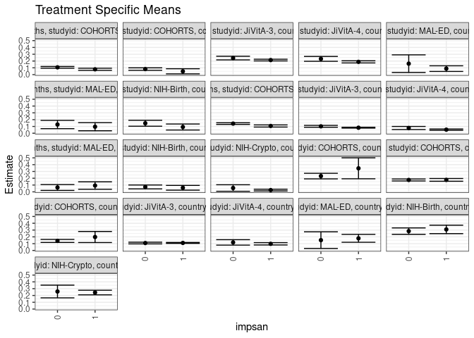

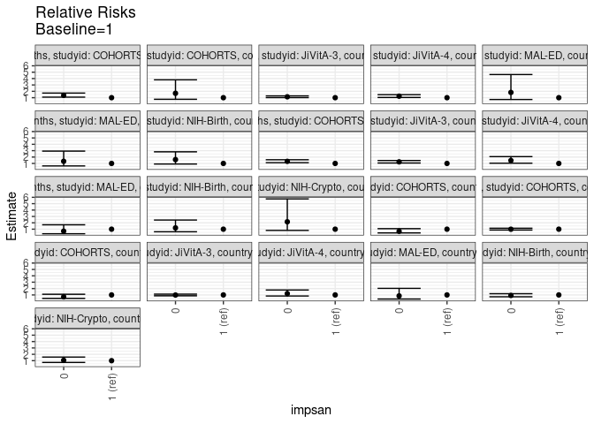

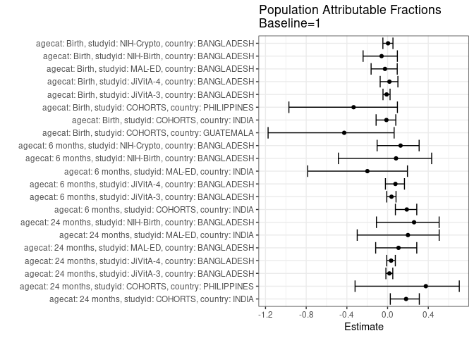

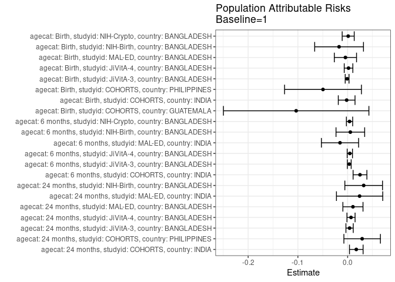

## Results Table

### Parameter: TSM

| agecat | studyid | country | intervention_level | baseline_level | estimate | ci_lower | ci_upper |
| --- | --- | --- | --- | --- | --- | --- | --- |
| Birth | COHORTS | GUATEMALA | 1 | NA | 0.3462501 | 0.1920885 | 0.5004117 |
| Birth | COHORTS | GUATEMALA | 0 | NA | 0.2317924 | 0.1906290 | 0.2729558 |
| Birth | COHORTS | INDIA | 1 | NA | 0.1759316 | 0.1557006 | 0.1961627 |
| Birth | COHORTS | INDIA | 0 | NA | 0.1748889 | 0.1603868 | 0.1893911 |
| Birth | COHORTS | PHILIPPINES | 1 | NA | 0.1978384 | 0.1165336 | 0.2791431 |
| Birth | COHORTS | PHILIPPINES | 0 | NA | 0.1403607 | 0.1179047 | 0.1628167 |
| Birth | JiVitA-3 | BANGLADESH | 1 | NA | 0.1106721 | 0.1040841 | 0.1172600 |
| Birth | JiVitA-3 | BANGLADESH | 0 | NA | 0.1089846 | 0.0964136 | 0.1215555 |
| Birth | JiVitA-4 | BANGLADESH | 1 | NA | 0.0976023 | 0.0802662 | 0.1149384 |
| Birth | JiVitA-4 | BANGLADESH | 0 | NA | 0.1184420 | 0.0785262 | 0.1583578 |
| Birth | MAL-ED | BANGLADESH | 1 | NA | 0.1785714 | 0.1205127 | 0.2366301 |
| Birth | MAL-ED | BANGLADESH | 0 | NA | 0.1515152 | 0.0288774 | 0.2741529 |
| Birth | NIH-Birth | BANGLADESH | 1 | NA | 0.3093840 | 0.2471699 | 0.3715981 |
| Birth | NIH-Birth | BANGLADESH | 0 | NA | 0.2842680 | 0.2369944 | 0.3315416 |
| Birth | NIH-Crypto | BANGLADESH | 1 | NA | 0.2431232 | 0.2090824 | 0.2771639 |
| Birth | NIH-Crypto | BANGLADESH | 0 | NA | 0.2584666 | 0.1651102 | 0.3518231 |
| 6 months | COHORTS | INDIA | 1 | NA | 0.1067222 | 0.0908719 | 0.1225726 |
| 6 months | COHORTS | INDIA | 0 | NA | 0.1417252 | 0.1293518 | 0.1540987 |
| 6 months | JiVitA-3 | BANGLADESH | 1 | NA | 0.0812777 | 0.0749027 | 0.0876528 |
| 6 months | JiVitA-3 | BANGLADESH | 0 | NA | 0.1015706 | 0.0875412 | 0.1156000 |
| 6 months | JiVitA-4 | BANGLADESH | 1 | NA | 0.0525716 | 0.0424774 | 0.0626658 |
| 6 months | JiVitA-4 | BANGLADESH | 0 | NA | 0.0769683 | 0.0542389 | 0.0996976 |
| 6 months | MAL-ED | INDIA | 1 | NA | 0.0925926 | 0.0378079 | 0.1473773 |
| 6 months | MAL-ED | INDIA | 0 | NA | 0.0640000 | 0.0210013 | 0.1069987 |
| 6 months | NIH-Birth | BANGLADESH | 1 | NA | 0.0597597 | 0.0251266 | 0.0943927 |
| 6 months | NIH-Birth | BANGLADESH | 0 | NA | 0.0720517 | 0.0433716 | 0.1007319 |
| 6 months | NIH-Crypto | BANGLADESH | 1 | NA | 0.0260163 | 0.0134265 | 0.0386060 |
| 6 months | NIH-Crypto | BANGLADESH | 0 | NA | 0.0561798 | 0.0083061 | 0.1040534 |
| 24 months | COHORTS | INDIA | 1 | NA | 0.0782220 | 0.0626745 | 0.0937695 |
| 24 months | COHORTS | INDIA | 0 | NA | 0.1069499 | 0.0940981 | 0.1198018 |
| 24 months | COHORTS | PHILIPPINES | 1 | NA | 0.0483871 | 0.0105994 | 0.0861748 |
| 24 months | COHORTS | PHILIPPINES | 0 | NA | 0.0817031 | 0.0634823 | 0.0999239 |
| 24 months | JiVitA-3 | BANGLADESH | 1 | NA | 0.2140515 | 0.2015737 | 0.2265294 |
| 24 months | JiVitA-3 | BANGLADESH | 0 | NA | 0.2435892 | 0.2167495 | 0.2704289 |
| 24 months | JiVitA-4 | BANGLADESH | 1 | NA | 0.1877072 | 0.1719170 | 0.2034974 |
| 24 months | JiVitA-4 | BANGLADESH | 0 | NA | 0.2320429 | 0.1964037 | 0.2676820 |
| 24 months | MAL-ED | BANGLADESH | 1 | NA | 0.0883978 | 0.0469445 | 0.1298511 |
| 24 months | MAL-ED | BANGLADESH | 0 | NA | 0.1612903 | 0.0315115 | 0.2910692 |
| 24 months | MAL-ED | INDIA | 1 | NA | 0.0959746 | 0.0359858 | 0.1559634 |
| 24 months | MAL-ED | INDIA | 0 | NA | 0.1282294 | 0.0673058 | 0.1891530 |
| 24 months | NIH-Birth | BANGLADESH | 1 | NA | 0.0915893 | 0.0474873 | 0.1356913 |
| 24 months | NIH-Birth | BANGLADESH | 0 | NA | 0.1466835 | 0.1030680 | 0.1902989 |

### Parameter: E(Y)

| agecat | studyid | country | intervention_level | baseline_level | estimate | ci_lower | ci_upper |
| --- | --- | --- | --- | --- | --- | --- | --- |
| Birth | COHORTS | GUATEMALA | NA | NA | 0.2427617 | 0.2030594 | 0.2824640 |
| Birth | COHORTS | INDIA | NA | NA | 0.1739520 | 0.1628271 | 0.1850770 |
| Birth | COHORTS | PHILIPPINES | NA | NA | 0.1483126 | 0.1275443 | 0.1690809 |
| Birth | JiVitA-3 | BANGLADESH | NA | NA | 0.1096104 | 0.1044820 | 0.1147387 |
| Birth | JiVitA-4 | BANGLADESH | NA | NA | 0.0994152 | 0.0840401 | 0.1147903 |
| Birth | MAL-ED | BANGLADESH | NA | NA | 0.1741294 | 0.1215730 | 0.2266857 |
| Birth | NIH-Birth | BANGLADESH | NA | NA | 0.2921739 | 0.2549711 | 0.3293768 |
| Birth | NIH-Crypto | BANGLADESH | NA | NA | 0.2442529 | 0.2123108 | 0.2761950 |
| 6 months | COHORTS | INDIA | NA | NA | 0.1315471 | 0.1221436 | 0.1409506 |
| 6 months | JiVitA-3 | BANGLADESH | NA | NA | 0.0845406 | 0.0797300 | 0.0893513 |
| 6 months | JiVitA-4 | BANGLADESH | NA | NA | 0.0569712 | 0.0481278 | 0.0658146 |
| 6 months | MAL-ED | INDIA | NA | NA | 0.0772532 | 0.0428971 | 0.1116093 |
| 6 months | NIH-Birth | BANGLADESH | NA | NA | 0.0651769 | 0.0442802 | 0.0860736 |
| 6 months | NIH-Crypto | BANGLADESH | NA | NA | 0.0298295 | 0.0172543 | 0.0424048 |
| 24 months | COHORTS | INDIA | NA | NA | 0.0955961 | 0.0861511 | 0.1050412 |
| 24 months | COHORTS | PHILIPPINES | NA | NA | 0.0775428 | 0.0608996 | 0.0941860 |
| 24 months | JiVitA-3 | BANGLADESH | NA | NA | 0.2179681 | 0.2080916 | 0.2278446 |
| 24 months | JiVitA-4 | BANGLADESH | NA | NA | 0.1945032 | 0.1812962 | 0.2077102 |
| 24 months | MAL-ED | BANGLADESH | NA | NA | 0.0990566 | 0.0587480 | 0.1393652 |
| 24 months | MAL-ED | INDIA | NA | NA | 0.1200000 | 0.0774445 | 0.1625555 |
| 24 months | NIH-Birth | BANGLADESH | NA | NA | 0.1238318 | 0.0925894 | 0.1550741 |

### Parameter: RR

| agecat | studyid | country | intervention_level | baseline_level | estimate | ci_lower | ci_upper |
| --- | --- | --- | --- | --- | --- | --- | --- |
| Birth | COHORTS | GUATEMALA | 1 | 1 | 1.0000000 | 1.0000000 | 1.000000 |
| Birth | COHORTS | GUATEMALA | 0 | 1 | 0.6694363 | 0.4144748 | 1.081236 |
| Birth | COHORTS | INDIA | 1 | 1 | 1.0000000 | 1.0000000 | 1.000000 |
| Birth | COHORTS | INDIA | 0 | 1 | 0.9940732 | 0.8627918 | 1.145330 |
| Birth | COHORTS | PHILIPPINES | 1 | 1 | 1.0000000 | 1.0000000 | 1.000000 |
| Birth | COHORTS | PHILIPPINES | 0 | 1 | 0.7094716 | 0.4564046 | 1.102859 |
| Birth | JiVitA-3 | BANGLADESH | 1 | 1 | 1.0000000 | 1.0000000 | 1.000000 |
| Birth | JiVitA-3 | BANGLADESH | 0 | 1 | 0.9847523 | 0.8637240 | 1.122740 |
| Birth | JiVitA-4 | BANGLADESH | 1 | 1 | 1.0000000 | 1.0000000 | 1.000000 |
| Birth | JiVitA-4 | BANGLADESH | 0 | 1 | 1.2135168 | 0.8304931 | 1.773191 |
| Birth | MAL-ED | BANGLADESH | 1 | 1 | 1.0000000 | 1.0000000 | 1.000000 |
| Birth | MAL-ED | BANGLADESH | 0 | 1 | 0.8484848 | 0.3546686 | 2.029857 |
| Birth | NIH-Birth | BANGLADESH | 1 | 1 | 1.0000000 | 1.0000000 | 1.000000 |
| Birth | NIH-Birth | BANGLADESH | 0 | 1 | 0.9188195 | 0.7084061 | 1.191731 |
| Birth | NIH-Crypto | BANGLADESH | 1 | 1 | 1.0000000 | 1.0000000 | 1.000000 |
| Birth | NIH-Crypto | BANGLADESH | 0 | 1 | 1.0631099 | 0.7219815 | 1.565418 |
| 6 months | COHORTS | INDIA | 1 | 1 | 1.0000000 | 1.0000000 | 1.000000 |
| 6 months | COHORTS | INDIA | 0 | 1 | 1.3279823 | 1.1179194 | 1.577517 |
| 6 months | JiVitA-3 | BANGLADESH | 1 | 1 | 1.0000000 | 1.0000000 | 1.000000 |
| 6 months | JiVitA-3 | BANGLADESH | 0 | 1 | 1.2496737 | 1.0678525 | 1.462453 |
| 6 months | JiVitA-4 | BANGLADESH | 1 | 1 | 1.0000000 | 1.0000000 | 1.000000 |
| 6 months | JiVitA-4 | BANGLADESH | 0 | 1 | 1.4640654 | 1.0364530 | 2.068099 |
| 6 months | MAL-ED | INDIA | 1 | 1 | 1.0000000 | 1.0000000 | 1.000000 |
| 6 months | MAL-ED | INDIA | 0 | 1 | 0.6912000 | 0.2823598 | 1.692017 |
| 6 months | NIH-Birth | BANGLADESH | 1 | 1 | 1.0000000 | 1.0000000 | 1.000000 |
| 6 months | NIH-Birth | BANGLADESH | 0 | 1 | 1.2056914 | 0.5965109 | 2.436991 |
| 6 months | NIH-Crypto | BANGLADESH | 1 | 1 | 1.0000000 | 1.0000000 | 1.000000 |
| 6 months | NIH-Crypto | BANGLADESH | 0 | 1 | 2.1594101 | 0.8104761 | 5.753473 |
| 24 months | COHORTS | INDIA | 1 | 1 | 1.0000000 | 1.0000000 | 1.000000 |
| 24 months | COHORTS | INDIA | 0 | 1 | 1.3672612 | 1.0849752 | 1.722992 |
| 24 months | COHORTS | PHILIPPINES | 1 | 1 | 1.0000000 | 1.0000000 | 1.000000 |
| 24 months | COHORTS | PHILIPPINES | 0 | 1 | 1.6885309 | 0.7495319 | 3.803889 |
| 24 months | JiVitA-3 | BANGLADESH | 1 | 1 | 1.0000000 | 1.0000000 | 1.000000 |
| 24 months | JiVitA-3 | BANGLADESH | 0 | 1 | 1.1379933 | 1.0104957 | 1.281578 |
| 24 months | JiVitA-4 | BANGLADESH | 1 | 1 | 1.0000000 | 1.0000000 | 1.000000 |
| 24 months | JiVitA-4 | BANGLADESH | 0 | 1 | 1.2361960 | 1.0346261 | 1.477037 |
| 24 months | MAL-ED | BANGLADESH | 1 | 1 | 1.0000000 | 1.0000000 | 1.000000 |
| 24 months | MAL-ED | BANGLADESH | 0 | 1 | 1.8245968 | 0.7189612 | 4.630505 |
| 24 months | MAL-ED | INDIA | 1 | 1 | 1.0000000 | 1.0000000 | 1.000000 |
| 24 months | MAL-ED | INDIA | 0 | 1 | 1.3360766 | 0.6087605 | 2.932353 |
| 24 months | NIH-Birth | BANGLADESH | 1 | 1 | 1.0000000 | 1.0000000 | 1.000000 |
| 24 months | NIH-Birth | BANGLADESH | 0 | 1 | 1.6015355 | 0.9085174 | 2.823189 |

### Parameter: PAR

| agecat | studyid | country | intervention_level | baseline_level | estimate | ci_lower | ci_upper |
| --- | --- | --- | --- | --- | --- | --- | --- |
| Birth | COHORTS | GUATEMALA | 1 | NA | -0.1034884 | -0.2497101 | 0.0427334 |
| Birth | COHORTS | INDIA | 1 | NA | -0.0019796 | -0.0187890 | 0.0148297 |
| Birth | COHORTS | PHILIPPINES | 1 | NA | -0.0495258 | -0.1267988 | 0.0277473 |
| Birth | JiVitA-3 | BANGLADESH | 1 | NA | -0.0010617 | -0.0048719 | 0.0027485 |
| Birth | JiVitA-4 | BANGLADESH | 1 | NA | 0.0018129 | -0.0068501 | 0.0104759 |
| Birth | MAL-ED | BANGLADESH | 1 | NA | -0.0044421 | -0.0267622 | 0.0178781 |
| Birth | NIH-Birth | BANGLADESH | 1 | NA | -0.0172101 | -0.0662498 | 0.0318296 |
| Birth | NIH-Crypto | BANGLADESH | 1 | NA | 0.0011297 | -0.0109634 | 0.0132228 |
| 6 months | COHORTS | INDIA | 1 | NA | 0.0248249 | 0.0109520 | 0.0386978 |
| 6 months | JiVitA-3 | BANGLADESH | 1 | NA | 0.0032629 | -0.0005718 | 0.0070976 |
| 6 months | JiVitA-4 | BANGLADESH | 1 | NA | 0.0043996 | -0.0009165 | 0.0097157 |
| 6 months | MAL-ED | INDIA | 1 | NA | -0.0153394 | -0.0527469 | 0.0220682 |
| 6 months | NIH-Birth | BANGLADESH | 1 | NA | 0.0054172 | -0.0233812 | 0.0342156 |
| 6 months | NIH-Crypto | BANGLADESH | 1 | NA | 0.0038133 | -0.0024884 | 0.0101150 |
| 24 months | COHORTS | INDIA | 1 | NA | 0.0173741 | 0.0036923 | 0.0310559 |
| 24 months | COHORTS | PHILIPPINES | 1 | NA | 0.0291557 | -0.0075634 | 0.0658748 |
| 24 months | JiVitA-3 | BANGLADESH | 1 | NA | 0.0039166 | -0.0034530 | 0.0112862 |
| 24 months | JiVitA-4 | BANGLADESH | 1 | NA | 0.0067960 | -0.0013730 | 0.0149650 |
| 24 months | MAL-ED | BANGLADESH | 1 | NA | 0.0106588 | -0.0095637 | 0.0308813 |
| 24 months | MAL-ED | INDIA | 1 | NA | 0.0240254 | -0.0225032 | 0.0705540 |
| 24 months | NIH-Birth | BANGLADESH | 1 | NA | 0.0322425 | -0.0056250 | 0.0701100 |

### Parameter: PAF

| agecat | studyid | country | intervention_level | baseline_level | estimate | ci_lower | ci_upper |
| --- | --- | --- | --- | --- | --- | --- | --- |
| Birth | COHORTS | GUATEMALA | 1 | NA | -0.4262962 | -1.1745155 | 0.0644716 |
| Birth | COHORTS | INDIA | 1 | NA | -0.0113803 | -0.1127760 | 0.0807763 |
| Birth | COHORTS | PHILIPPINES | 1 | NA | -0.3339282 | -0.9699646 | 0.0967532 |
| Birth | JiVitA-3 | BANGLADESH | 1 | NA | -0.0096861 | -0.0450251 | 0.0244579 |
| Birth | JiVitA-4 | BANGLADESH | 1 | NA | 0.0182358 | -0.0728120 | 0.1015564 |
| Birth | MAL-ED | BANGLADESH | 1 | NA | -0.0255102 | -0.1618982 | 0.0948681 |
| Birth | NIH-Birth | BANGLADESH | 1 | NA | -0.0589035 | -0.2407813 | 0.0963141 |
| Birth | NIH-Crypto | BANGLADESH | 1 | NA | 0.0046252 | -0.0461349 | 0.0529223 |
| 6 months | COHORTS | INDIA | 1 | NA | 0.1887149 | 0.0768595 | 0.2870169 |
| 6 months | JiVitA-3 | BANGLADESH | 1 | NA | 0.0385956 | -0.0080804 | 0.0831104 |
| 6 months | JiVitA-4 | BANGLADESH | 1 | NA | 0.0772251 | -0.0211739 | 0.1661424 |
| 6 months | MAL-ED | INDIA | 1 | NA | -0.1985597 | -0.7855318 | 0.1954524 |
| 6 months | NIH-Birth | BANGLADESH | 1 | NA | 0.0831156 | -0.4834900 | 0.4333114 |
| 6 months | NIH-Crypto | BANGLADESH | 1 | NA | 0.1278358 | -0.1028159 | 0.3102472 |
| 24 months | COHORTS | INDIA | 1 | NA | 0.1817449 | 0.0268779 | 0.3119657 |
| 24 months | COHORTS | PHILIPPINES | 1 | NA | 0.3759950 | -0.3196083 | 0.7049259 |
| 24 months | JiVitA-3 | BANGLADESH | 1 | NA | 0.0179686 | -0.0164630 | 0.0512339 |
| 24 months | JiVitA-4 | BANGLADESH | 1 | NA | 0.0349402 | -0.0081499 | 0.0761886 |
| 24 months | MAL-ED | BANGLADESH | 1 | NA | 0.1076033 | -0.1170077 | 0.2870488 |
| 24 months | MAL-ED | INDIA | 1 | NA | 0.2002117 | -0.2983115 | 0.5073129 |
| 24 months | NIH-Birth | BANGLADESH | 1 | NA | 0.2603734 | -0.1094293 | 0.5069109 |